# CPLN 675 Midterm: Flood Inundation Prediction

Mia Cherayil, Mariya Lupandina, and Henry Feinstein

3/30/2022

# 1. Introduction: Planning Motivation

The worsening effects of climate change mean that the average 100-year floodplain in Canadian river cities is projected to expand by 45% by the year 2100 – increasing the likelihood of irreversible destruction to human life, private property, businesses, and valuable natural resources. Consequently, flooding events are also disastrous for national economies, causing annual average losses in the billions. In 2013, Calgary experienced its worst flood since 1932 due to heavy rainfall and other environmental factors. Many other river cities are also seeing an increase in flood frequency and intensity.

Given the urgency of this issue, this report presents a model based on data from the Calgary flood to predict inundation in other comparable river cities and uses Edmonton to test the model’s efficacy. The inundation model’s intent is to provide guidance to cities on what resources or hazards to prioritize in their protection efforts during the Hazard Mitigation planning process.

# 2. Mapping Statistically Significant Variables

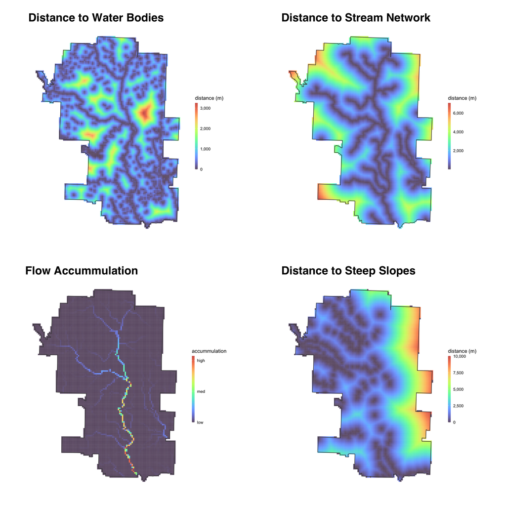

```r
grid.arrange(ncol = 2,
ggplot(data = calgary) +
  geom_sf(aes(fill = hydro_dis),
          color = "transparent",
          alpha = 0.75) +
    scale_fill_viridis(
                      alpha = .75,
                      begin = 0,
                      end = 0.9,
                      direction = 1,
                      discrete = FALSE,
                      option = "H",
                      labels = comma) +
  geom_sf(data=calgary_boundary,
          fill = "transparent",
          color = "#474747",
          size = .5) +
  labs(title ="Distance to Water Bodies",
       fill = "distance (m)")+
    mapTheme,

ggplot(data = calgary) +
  geom_sf(aes(fill = stream_dis),
          color = "transparent",
          alpha = 0.75) +
      scale_fill_viridis(
                      alpha = .75,
                      begin = 0,
                      end = 0.9,
                      direction = 1,
                      discrete = FALSE,
                      option = "H",
                      labels = comma) +
  geom_sf(data=calgary_boundary,
          fill = "transparent",
          color = "#474747",
          size = .5) +
  labs(title ="Distance to Stream Network",
       fill = "distance (m)")+
    mapTheme,

ggplot(data = calgary) +
  geom_sf(aes(fill = fac_sum),
          color = "transparent",
          alpha = 0.75) +
      scale_fill_viridis(
                      alpha = .75,
                      begin = 0,
                      end = 0.9,
                      direction = 1,
                      discrete = FALSE,
                      option = "H",
                      breaks = c(0, 12500000, 25000000),
                      labels = c("low", "med", "high")) +
  geom_sf(data=calgary_boundary,
          fill = "transparent",
          color = "#474747",
          size = .5) +
  labs(title ="Flow Accummulation",
       fill = "accummulation")+
    mapTheme,

ggplot(data = calgary) +
  geom_sf(aes(fill = dist_steep),
          color = "transparent",
          alpha = 0.75) +
      scale_fill_viridis(
                      alpha = .75,
                      begin = 0,
                      end = 0.9,
                      direction = 1,
                      discrete = FALSE,
                      option = "H",
                      labels = comma) +
  geom_sf(data=calgary_boundary,
          fill = "transparent",
          color = "#474747",
          size = .5) +
  labs(title="Distance to Steep Slopes",
       fill = "distance (m)")+
    mapTheme
)
```

To build the inundation model we included the following six features: (1) distance to all water bodies, (2) distance to stream network, (3) flow accumulation sum for each cell, (4) distance to steep slopes. (5) slope categorization – flat to very steep, and (6) percent of cell that is impervious. Among these six features the first four proved to be the most statistically significant. It is notable that the most significant features are all related to elevation and/or hydrology. The slope categorization variable was also later excluded from our model for visualization purposes.

# 3. Logistic Regression Model Summary

```r
# regression model summary
summary(calgaryModel)
```

```
##
## Call:
## glm(formula = inundation ~ ., family = binomial(link = "logit"),
##     data = calgaryTrain %>% as.data.frame() %>% select(-geometry))
##
## Deviance Residuals:
##     Min       1Q   Median       3Q      Max
## -2.3212  -0.4120  -0.1688  -0.0344   4.7721
##
## Coefficients:
##                                 Estimate      Std. Error z value
## (Intercept)                1.29366691476   0.15882624186   8.145
## stream_dis                -0.00042098220   0.00004669501  -9.016
## hydro_dis                 -0.00509986597   0.00025093582 -20.323
## imp_pct                    0.14170827233   0.17887497793   0.792
## fac_sum                    0.00000015987   0.00000003138   5.094
## dist_steep                -0.00054334539   0.00003874579 -14.023
## slope                      0.04196388641   0.04854904224   0.864
## slope_catGentle           -0.64699484348   0.13951767548  -4.637
## slope_catModerate-Strong  -0.04488995288   0.34026055773  -0.132
## slope_catSteep           -13.17905295107 324.74478727989  -0.041
##                                      Pr(>|z|)
## (Intercept)              0.000000000000000379 ***
## stream_dis               < 0.0000000000000002 ***
## hydro_dis                < 0.0000000000000002 ***
## imp_pct                                 0.428
## fac_sum                  0.000000350560593664 ***
## dist_steep               < 0.0000000000000002 ***
## slope                                   0.387
## slope_catGentle          0.000003528733351207 ***
## slope_catModerate-Strong                0.895
## slope_catSteep                          0.968
## ---
## Signif. codes:  0 '***' 0.001 '**' 0.01 '*' 0.05 '.' 0.1 ' ' 1
##
## (Dispersion parameter for binomial family taken to be 1)
##
##     Null deviance: 4957.9  on 6782  degrees of freedom
## Residual deviance: 3123.5  on 6773  degrees of freedom
##   (38 observations deleted due to missingness)
## AIC: 3143.5
##
## Number of Fisher Scoring iterations: 11
```

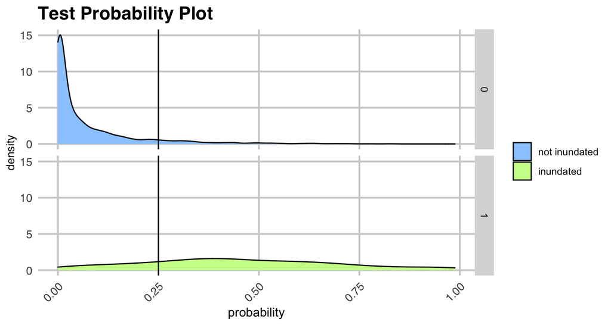

```r
# probability density curve
ggplot(testProbs, aes(x = pred, fill=as.factor(obs))) +
  geom_density() +
  facet_grid(obs ~ .) +
  xlab("probability") +
  geom_vline(xintercept = .25, show.legend = TRUE) +
  scale_fill_manual(values = c("#99ccff", "#ccff99"),
                      labels = c("not inundated","inundated"),
                      name = "")+
  labs(title="Test Probability Plot")+
  plotTheme
```

This test probability plot shows the predicted probabilities for inundated and non-inundated cells. Based on the distributions seen here, we chose 0.25 as the cutoff value for classifying a cell as inundated.

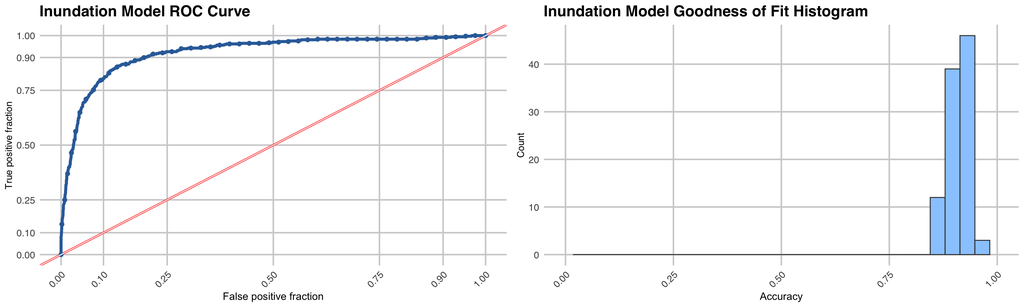

```r
# ROC curve
grid.arrange(ncol = 2,
ggplot(testProbs, aes(d = obs, m = pred)) +
      geom_abline(slope = 1, intercept = 0, size = 1, color = "red")+
      geom_roc(n.cuts = 50, labels = FALSE, size = 1.5, color ="#326da8") + #i think i'm not understanding something, but shouldn't 50 be 40 bc that the cut off that was used earlier? This one, 50 is okay - it's just saying the number of points on the ROC line to show (I believe). But elsewhere I am changing it
  style_roc(theme = theme_grey) +
  labs(title="Inundation Model ROC Curve")+
  plotTheme,

#Goodness of Fit Histogram
ggplot(as.data.frame(cvFit$resample), aes(Accuracy)) +
  geom_histogram(color="#474747", fill="#99ccff") +
  scale_x_continuous(limits = c(0, 1)) +
  labs(title="Inundation Model Goodness of Fit Histogram",
       x="Accuracy",
       y="Count")+
  plotTheme
)
```

```r
# confusion metrics
caret::confusionMatrix(reference = as.factor(testProbs$obs),
                       data = as.factor(testProbs$predClass),
                       positive = "1")
```

```
## Confusion Matrix and Statistics
##
##           Reference
## Prediction    0    1
##          0 2317   80
##          1  220  288
##
##                Accuracy : 0.8967
##                  95% CI : (0.8851, 0.9076)
##     No Information Rate : 0.8733
##     P-Value [Acc > NIR] : 0.000055483767704240
##
##                   Kappa : 0.5986
##
##  Mcnemar's Test P-Value : 0.000000000000001014
##
##             Sensitivity : 0.78261
##             Specificity : 0.91328
##          Pos Pred Value : 0.56693
##          Neg Pred Value : 0.96662
##              Prevalence : 0.12668
##          Detection Rate : 0.09914
##    Detection Prevalence : 0.17487
##       Balanced Accuracy : 0.84795
##
##        'Positive' Class : 1
##
```

```r
# cross-validation summary
cvFit
```

```
## Generalized Linear Model
##
## 9741 samples
##    6 predictor
##    2 classes: '0', '1'
##
## No pre-processing
## Resampling: Cross-Validated (100 fold)
## Summary of sample sizes: 9643, 9643, 9643, 9644, 9643, 9644, ...
## Resampling results:
##
##   Accuracy   Kappa
##   0.9101618  0.4726972
```

Given that the area under the ROC curve is almost 1 and that the distribution of predictions is clustered around 0.9, this model is performing well.

# 4. Calgary Training Set Results Map

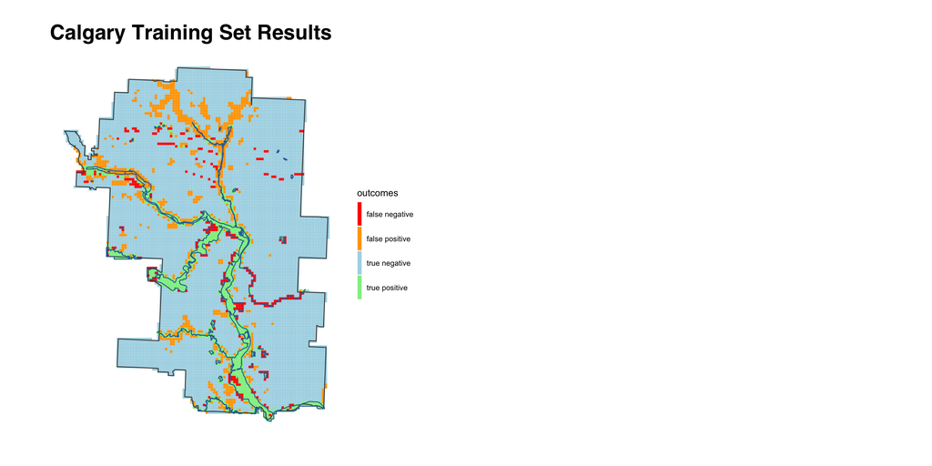

```r
grid.arrange(ncol = 2,
calgary %>%
  mutate(confResult=case_when(allPredictions < 25 & inundation==0 ~ "True_Negative",
                              allPredictions >= 25 & inundation==1 ~ "True_Positive",
                              allPredictions < 25 & inundation==1 ~ "False_Negative",
                              allPredictions >= 25 & inundation==0 ~ "False_Positive")) %>%
  ggplot()+
  geom_sf(aes(fill = confResult), color = "transparent")+
  scale_fill_manual(values = c("Red","Orange","Light Blue","Light Green"),
                    labels = c("false negative", "false positive", "true negative", "true positive"))+
  geom_sf(data=calgary_boundary,
          fill = "transparent",
          color = "#474747",
          size = .5)+
  geom_sf(data=calgary_flooding,
          fill = "transparent",
          color = "#326da8",
          size = .5)+
  labs(title = "Calgary Training Set Results",
       fill = "outcomes") +
  mapTheme
)
```

While our model performs fairly well, it does appear to over-predict flooding in the northern and western areas of the city. However, over-predicting is a preferable outcome to under-predicting flooding risk given the unpredictable nature of climate change’s impacts.

# 5. Inundation Predictions Map

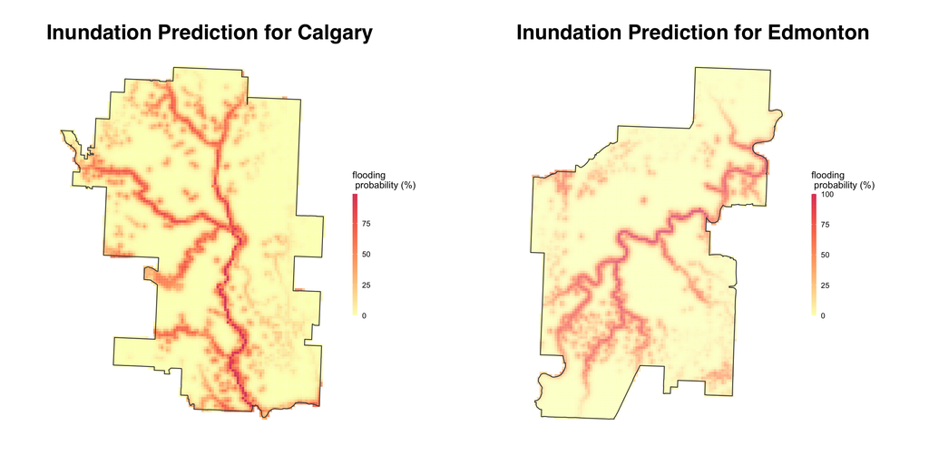

```r
grid.arrange(ncol = 2,
calgary %>%
  ggplot()+
  geom_sf(aes(fill = allPredictions),
          color = "transparent",
          apha = 0.75)+
  geom_sf(data=calgary_boundary,
          fill = "transparent",
          color = "#474747",
          size = .5)+
  scale_fill_viridis(
                      alpha = 1,
                      begin = 1,
                      end = 0.6,
                      direction = 1,
                      discrete = FALSE,
                      option = "A") +
  labs(title="Inundation Prediction for Calgary",
       fill = "flooding\n probability (%)")+
  mapTheme,

edmonton %>%
  ggplot()+
  geom_sf(aes(fill = allPredictions_ed),
          color = "transparent",
          alpha = 0.75) +
  scale_fill_viridis(
                      alpha = 1,
                      begin = 1,
                      end = 0.6,
                      direction = 1,
                      discrete = FALSE,
                      option = "A") +
  geom_sf(data=edmonton_boundary,
          fill = "transparent",
          color = "#474747",
          size = .5)+
  labs(title="Inundation Prediction for Edmonton",
       fill = "flooding\n probability (%)")+
  mapTheme
)
```

This model should only be applied to cities with a similar environmental and geographic profile, such as Edmonton, Alberta, which is shown in the map on the right. The model predicts similar flooding patterns centered around the main river in both cities.

Video Link: https://penno365-my.sharepoint.com/:v:/g/personal/mlup_upenn_edu/ERrkit4F7rhDiSz6WMEOpfEBNqXBuwkatXZBvgdklLBECg?e=MCGia1